# The Critical Influence of Air Pollution and Socioeconomic Status on Cardiovascular Disease Mortality Rates in the U.S. with Public Health and Social Justice Implications

```python
# This is the number of rows and columns in the data
df_annualcounty_pm25_cmr.shape
```

```
(44772, 7)
```

The dataframe has 44772 rows and 7 columns. The total number of datapoints expected is 313404

```python
df_county_sespm25_index_quintile.shape
```

```
(2132, 10)
```

The dataframe has 2132 rows and 10 columns. The total number of datapoints expected is 21320

```python
df_county_sespm25_index_quintile.info()
```

```
<class 'pandas.core.frame.DataFrame'>
RangeIndex: 2132 entries, 0 to 2131
Data columns (total 10 columns):
 #   Column             Non-Null Count  Dtype
---  ------             --------------  -----
 0   Unnamed: 0         2132 non-null   int64
 1   FIPS               2132 non-null   int64
 2   SES_index_1990     2132 non-null   float64
 3   SES_index_2000     2132 non-null   float64
 4   SES_index_2010     2132 non-null   float64
 5   SES_quintile_1990  2132 non-null   object
 6   SES_quintile_2000  2132 non-null   object
 7   SES_quintile_2010  2132 non-null   object
 8   fip_state          2132 non-null   int64
 9   state              2132 non-null   object
dtypes: float64(3), int64(3), object(4)
memory usage: 166.7+ KB
```

```python
df_heart_dx_mort.shape
```

```
(501, 5)
```

The dataframe has 501 rows and 5 columns. The total number of datapoints expected is 2505

```python
df_heart_dx_mort.info()
```

```
<class 'pandas.core.frame.DataFrame'>
RangeIndex: 501 entries, 0 to 500
Data columns (total 5 columns):
 #   Column  Non-Null Count  Dtype
---  ------  --------------  -----
 0   YEAR    501 non-null    int64
 1   STATE   501 non-null    object
 2   RATE    501 non-null    float64
 3   DEATHS  501 non-null    object
 4   URL     501 non-null    object
dtypes: float64(1), int64(1), object(3)
memory usage: 19.7+ KB
```

```python
df_htn_dx_mort.shape
```

```
(501, 5)
```

The dataframe has 501 rows and 5 columns. The total number of datapoints expected is 2505

```python
df_htn_dx_mort.info()
```

```
<class 'pandas.core.frame.DataFrame'>
RangeIndex: 501 entries, 0 to 500
Data columns (total 5 columns):
 #   Column  Non-Null Count  Dtype
---  ------  --------------  -----
 0   YEAR    501 non-null    int64
 1   STATE   501 non-null    object
 2   RATE    501 non-null    float64
 3   DEATHS  501 non-null    object
 4   URL     501 non-null    object
dtypes: float64(1), int64(1), object(3)
memory usage: 19.7+ KB
```

```python
df_acs_2009_2010_states.shape
```

```
(104, 20)
```

The dataframe has 104 rows and 20 columns. The total number of datapoints expected is 2080

```python
df_acs_2009_2010_states.info()
```

```
<class 'pandas.core.frame.DataFrame'>
RangeIndex: 104 entries, 0 to 103
Data columns (total 20 columns):
 #   Column                         Non-Null Count  Dtype
---  ------                         --------------  -----
 0   state                          104 non-null    object
 1   median_income                  104 non-null    int64
 2   total_population_poverty       104 non-null    int64
 3   poverty_count                  104 non-null    int64
 4   total_population_uninsured     104 non-null    int64
 5   uninsured_count                104 non-null    int64
 6   total_population_education_18  104 non-null    int64
 7   high_school_diploma            104 non-null    int64
 8   ged_alternative                104 non-null    int64
 9   associates_degree              104 non-null    int64
 10  bachelors_degree               104 non-null    int64
 11  masters_degree                 104 non-null    int64
 12  professional_degree            104 non-null    int64
 13  doctorate_degree               104 non-null    int64
 14  fip                            104 non-null    int64
 15  poverty_rate                   104 non-null    float64
 16  uninsured_rate                 104 non-null    float64
 17  educated_adults                104 non-null    int64
 18  education_percent_educated_18  104 non-null    float64
 19  year                           104 non-null    int64
dtypes: float64(3), int64(16), object(1)
memory usage: 16.4+ KB
```

```python
df_annualcounty_pm25_cmr['state'].unique()
```

```
array(['AL', 'AZ', 'AR', 'CA', 'CO', 'CT', 'DE', 'DC', 'FL', 'GA', 'ID',
       'IL', 'IN', 'IA', 'KS', 'KY', 'LA', 'ME', 'MD', 'MA', 'MI', 'MN',
       'MS', 'MO', 'MT', 'NE', 'NV', 'NH', 'NJ', 'NM', 'NY', 'NC', 'ND',
       'OH', 'OK', 'OR', 'PA', 'RI', 'SC', 'SD', 'TN', 'TX', 'UT', 'VT',
       'VA', 'WA', 'WV', 'WI', 'WY'], dtype=object)
```

```python
#create a list of the columns in the dataset
df_annualcounty_pm25_cmrCol = df_annualcounty_pm25_cmr.columns
df_annualcounty_pm25_cmrCol
```

```
Index(['Unnamed: 0', 'FIPS', 'Year', 'PM2.5', 'CMR', 'fip_state', 'state'], dtype='object')
```

```python
# Update the Headers for Consistency

df_annualcounty_pm25_cmrCol = df_annualcounty_pm25_cmr.rename(columns = {'Unnamed: 0':'indexes'})

# view the new columns and update the variable
df_annualcounty_pm25_cmr = df_annualcounty_pm25_cmrCol

df_annualcounty_pm25_cmr.head()
```

|  | indexes | FIPS | Year | PM2.5 | CMR | fip_state | state |
| --- | --- | --- | --- | --- | --- | --- | --- |
| 0 | 1 | 1001 | 1990 | 9.749792 | 471.758888 | 1 | AL |
| 1 | 2 | 1001 | 1991 | 9.069443 | 456.869651 | 1 | AL |
| 2 | 3 | 1001 | 1992 | 9.105352 | 520.014377 | 1 | AL |
| 3 | 4 | 1001 | 1993 | 8.752873 | 454.436425 | 1 | AL |
| 4 | 5 | 1001 | 1994 | 9.024049 | 415.035332 | 1 | AL |

Renamed the column "Unnamed:0' to indexes for a more explanatory dataset.

```python
df_annualcounty_pm25_cmr_filtered = df_annualcounty_pm25_cmr[(df_annualcounty_pm25_cmr['Year'] < 1990) | (df_annualcounty_pm25_cmr['Year'] > 2008)]
```

```python
df_annualcounty_pm25_cmr_filtered.tail()
```

|  | indexes | FIPS | Year | PM2.5 | CMR | fip_state | state |
| --- | --- | --- | --- | --- | --- | --- | --- |
| 44729 | 44730 | 56029 | 2010 | 2.571525 | 170.765285 | 56 | WY |
| 44749 | 44750 | 56033 | 2009 | 2.566431 | 235.312525 | 56 | WY |
| 44750 | 44751 | 56033 | 2010 | 2.642380 | 175.671813 | 56 | WY |
| 44770 | 44771 | 56037 | 2009 | 3.119896 | 242.828987 | 56 | WY |
| 44771 | 44772 | 56037 | 2010 | 3.230996 | 254.860863 | 56 | WY |

```python
df_annualstate_county_pm25_cmr = df_annualcounty_pm25_cmr_filtered

df_annualstate_county_pm25_cmr['state'].unique()
```

```
array(['AL', 'AZ', 'AR', 'CA', 'CO', 'CT', 'DE', 'DC', 'FL', 'GA', 'ID',
       'IL', 'IN', 'IA', 'KS', 'KY', 'LA', 'ME', 'MD', 'MA', 'MI', 'MN',
       'MS', 'MO', 'MT', 'NE', 'NV', 'NH', 'NJ', 'NM', 'NY', 'NC', 'ND',
       'OH', 'OK', 'OR', 'PA', 'RI', 'SC', 'SD', 'TN', 'TX', 'UT', 'VT',
       'VA', 'WA', 'WV', 'WI', 'WY'], dtype=object)
```

```python
# Determine the number of missing values
df_annualstate_county_pm25_cmr.isnull().sum()
```

```
indexes      0
FIPS         0
Year         0
PM2.5        0
CMR          0
fip_state    0
state        0
dtype: int64
```

```python
# Determine the percentage of missing values
# Typically less than five percent missing values may not affect the results
# More than 5% can be dropped, replaced with existing data, or imputed using mean or median.

def missing(Dataframe):
    print('Percentage of missing values in the dataset:\n',
          round((Dataframe.isnull().sum() *100/len(Dataframe)), 2).sort_values(ascending=False))


missing(df_annualstate_county_pm25_cmr)
```

```
Percentage of missing values in the dataset:
 indexes      0.0
FIPS         0.0
Year         0.0
PM2.5        0.0
CMR          0.0
fip_state    0.0
state        0.0
dtype: float64
```

I have no missing values in this dataset which is good for my analysis as it allows for a faster and complete statistical analysis, exploration and visualization

```python
# create a list of the columns in the dataset
df_county_sespm25_index_quintileCol = df_county_sespm25_index_quintile.columns
df_county_sespm25_index_quintileCol
```

```
Index(['Unnamed: 0', 'FIPS', 'SES_index_1990', 'SES_index_2000',
       'SES_index_2010', 'SES_quintile_1990', 'SES_quintile_2000',
       'SES_quintile_2010', 'fip_state', 'state'],
      dtype='object')
```

```python
# Update the Headers for Syntax Consistency

df_county_sespm25_index_quintileCol = df_county_sespm25_index_quintile.rename(columns = {'Unnamed: 0':'indexes'})

# view the new columns and update the variable

df_county_sespm25_index_quintile = df_county_sespm25_index_quintileCol

df_county_sespm25_index_quintile.head()
```

|  | indexes | FIPS | SES_index_1990 | SES_index_2000 | SES_index_2010 | SES_quintile_1990 | SES_quintile_2000 | SES_quintile_2010 | fip_state | state |
| --- | --- | --- | --- | --- | --- | --- | --- | --- | --- | --- |
| 0 | 1 | 1001 | -0.079387 | -0.322846 | -0.405150 | Q3 | Q3 | Q2 | 1 | AL |
| 1 | 2 | 1003 | -0.187240 | -0.467794 | -0.403987 | Q3 | Q2 | Q2 | 1 | AL |
| 2 | 3 | 1005 | 1.279538 | 2.013751 | 1.740142 | Q5 | Q5 | Q5 | 1 | AL |
| 3 | 4 | 1009 | 0.124421 | -0.375181 | -0.405849 | Q4 | Q3 | Q2 | 1 | AL |
| 4 | 5 | 1011 | 2.877256 | 3.519681 | 2.617074 | Q5 | Q5 | Q5 | 1 | AL |

Renamed the column "Unnamed:0' to indexes for a more explanatory dataset.

```python
# Determine the number of missing values

df_county_sespm25_index_quintile.isnull().sum()
```

```
indexes              0
FIPS                 0
SES_index_1990       0
SES_index_2000       0
SES_index_2010       0
SES_quintile_1990    0
SES_quintile_2000    0
SES_quintile_2010    0
fip_state            0
state                0
dtype: int64
```

```python
#  function to determine the percentage of missing values
# Typically less than five percent missing values may not affect the results
# More than 5% can be dropped, replaced with existing data, or imputed using mean or median.

def missing(Dataframe):
    print('Percentage of missing values in the dataset:\n',
          round((Dataframe.isnull().sum() *100/len(Dataframe)), 2).sort_values(ascending=False))


missing(df_county_sespm25_index_quintile)
```

```
Percentage of missing values in the dataset:
 indexes              0.0
FIPS                 0.0
SES_index_1990       0.0
SES_index_2000       0.0
SES_index_2010       0.0
SES_quintile_1990    0.0
SES_quintile_2000    0.0
SES_quintile_2010    0.0
fip_state            0.0
state                0.0
dtype: float64
```

```python
#create a list of the columns in the dataset
df_heart_dx_mortCol = df_heart_dx_mort.columns
df_heart_dx_mortCol
```

```
Index(['YEAR', 'STATE', 'RATE', 'DEATHS', 'URL'], dtype='object')
```

```python
#create a list of the columns in the dataset
df_heart_dx_mortCol = df_heart_dx_mort.columns
df_heart_dx_mortCol
```

```
Index(['YEAR', 'STATE', 'RATE', 'DEATHS', 'URL'], dtype='object')
```

```python
# Update the Headers for Consistency

df_heart_dx_mortCol = df_heart_dx_mort.rename(columns = {'STATE':'state'})

# view the new columns and update the variable

df_heart_dx_mort = df_heart_dx_mortCol

df_heart_dx_mort.head()
```

|  | YEAR | state | RATE | DEATHS | URL |
| --- | --- | --- | --- | --- | --- |
| 0 | 2022 | AL | 234.2 | 14958 | /nchs/pressroom/states/alabama/al.htm |
| 1 | 2022 | AK | 145.7 | 1013 | /nchs/pressroom/states/alaska/ak.htm |
| 2 | 2022 | AZ | 148.5 | 14593 | /nchs/pressroom/states/arizona/az.htm |
| 3 | 2022 | AR | 224.1 | 8664 | /nchs/pressroom/states/arkansas/ar.htm |
| 4 | 2022 | CA | 142.4 | 66340 | /nchs/pressroom/states/california/ca.htm |

Changed the column name 'STATE' to 'state' in this cardiovascular disease rate dataset to allign with similar column names in the other datasets for easier manipulation and merging if needed.

```python
df_heart_dx_mort.head()
```

|  | YEAR | state | RATE | DEATHS | URL |
| --- | --- | --- | --- | --- | --- |
| 0 | 2022 | AL | 234.2 | 14958 | /nchs/pressroom/states/alabama/al.htm |
| 1 | 2022 | AK | 145.7 | 1013 | /nchs/pressroom/states/alaska/ak.htm |
| 2 | 2022 | AZ | 148.5 | 14593 | /nchs/pressroom/states/arizona/az.htm |
| 3 | 2022 | AR | 224.1 | 8664 | /nchs/pressroom/states/arkansas/ar.htm |
| 4 | 2022 | CA | 142.4 | 66340 | /nchs/pressroom/states/california/ca.htm |

```python
# Load the dataset
df = df_heart_dx_mort

df['state'] = df['state'].replace({
    'District of Columbia' : 'DC',

})

# Save the updated dataset
df_heart_dx_mort = df


df_heart_dx_mort.head(5)
```

|  | YEAR | state | RATE | DEATHS | URL |
| --- | --- | --- | --- | --- | --- |
| 0 | 2022 | AL | 234.2 | 14958 | /nchs/pressroom/states/alabama/al.htm |
| 1 | 2022 | AK | 145.7 | 1013 | /nchs/pressroom/states/alaska/ak.htm |
| 2 | 2022 | AZ | 148.5 | 14593 | /nchs/pressroom/states/arizona/az.htm |
| 3 | 2022 | AR | 224.1 | 8664 | /nchs/pressroom/states/arkansas/ar.htm |
| 4 | 2022 | CA | 142.4 | 66340 | /nchs/pressroom/states/california/ca.htm |

Changed the variable 'District of columbia' to 'DC' in the state column for conformity with the rest of the dataset.

```python
print(df['state'].unique())
```

```
['AL' 'AK' 'AZ' 'AR' 'CA' 'CO' 'CT' 'DE' 'DC' 'FL' 'GA' 'HI' 'ID' 'IL'
 'IN' 'IA' 'KS' 'KY' 'LA' 'ME' 'MD' 'MA' 'MI' 'MN' 'MS' 'MO' 'MT' 'NE'
 'NV' 'NH' 'NJ' 'NM' 'NY' 'NC' 'ND' 'OH' 'OK' 'OR' 'PA' 'RI' 'SC' 'SD'
 'TN' 'TX' 'UT' 'VT' 'VA' 'WA' 'WV' 'WI' 'WY']
```

```python
# Determine the number of missing values

df_heart_dx_mort.isnull().sum()
```

```
YEAR      0
state     0
RATE      0
DEATHS    0
URL       0
dtype: int64
```

```python
def missing(Dataframe):
    print('Percentage of missing values in the dataset:\n',
          round((Dataframe.isnull().sum() *100/len(Dataframe)), 2).sort_values(ascending=False))


missing(df_heart_dx_mort)
```

```
Percentage of missing values in the dataset:
 YEAR      0.0
state     0.0
RATE      0.0
DEATHS    0.0
URL       0.0
dtype: float64
```

I have no missing values in this dataset which is also good for my analysis as it allows for a faster and complete statistical analysis, exploration and visualization

```python
#create a list of the columns in the dataset
df_htn_dx_mortCol = df_htn_dx_mort.columns
df_htn_dx_mortCol
```

```
Index(['YEAR', 'STATE', 'RATE', 'DEATHS', 'URL'], dtype='object')
```

Changed the column name 'STATE' to 'state' in this hypertensive disease rate dataset to allign with similar column names in the other datasets for easier manipulation and merging if needed.

```python
# Update the Headers for Consistency

df_htn_dx_mortCol = df_htn_dx_mort.rename(columns = {'STATE':'state'})

# view the new columns and update the variable

df_htn_dx_mort = df_htn_dx_mortCol

df_htn_dx_mort.head()
```

|  | YEAR | state | RATE | DEATHS | URL |
| --- | --- | --- | --- | --- | --- |
| 0 | 2022 | AL | 13.2 | 849 | /nchs/pressroom/states/alabama/al.htm |
| 1 | 2022 | AK | 8.6 | 56 | /nchs/pressroom/states/alaska/ak.htm |
| 2 | 2022 | AZ | 11.3 | 1109 | /nchs/pressroom/states/arizona/az.htm |
| 3 | 2022 | AR | 12.1 | 454 | /nchs/pressroom/states/arkansas/ar.htm |
| 4 | 2022 | CA | 14.4 | 6727 | /nchs/pressroom/states/california/ca.htm |

```python
# Load the dataset
df = df_htn_dx_mort

df['state'] = df['state'].replace({
    'District of Columbia' : 'DC',

})

# Save the updated dataset
df_htn_dx_mort = df


df_htn_dx_mort.head()
```

|  | YEAR | state | RATE | DEATHS | URL |
| --- | --- | --- | --- | --- | --- |
| 0 | 2022 | AL | 13.2 | 849 | /nchs/pressroom/states/alabama/al.htm |
| 1 | 2022 | AK | 8.6 | 56 | /nchs/pressroom/states/alaska/ak.htm |
| 2 | 2022 | AZ | 11.3 | 1109 | /nchs/pressroom/states/arizona/az.htm |
| 3 | 2022 | AR | 12.1 | 454 | /nchs/pressroom/states/arkansas/ar.htm |
| 4 | 2022 | CA | 14.4 | 6727 | /nchs/pressroom/states/california/ca.htm |

Changed the variable 'District of columbia' to 'DC' in the state column for conformity with the rest of the dataset.

```python
# number of missing values

df_htn_dx_mort.isnull().sum()
```

```
YEAR      0
state     0
RATE      0
DEATHS    0
URL       0
dtype: int64
```

```python
def missing(Dataframe):
    print('Percentage of missing values in the dataset:\n',
          round((Dataframe.isnull().sum() *100/len(Dataframe)), 2).sort_values(ascending=False))


missing(df_htn_dx_mort)
```

```
Percentage of missing values in the dataset:
 YEAR      0.0
state     0.0
RATE      0.0
DEATHS    0.0
URL       0.0
dtype: float64
```

I have no missing values in this dataset which is also good for my analysis as it allows for a faster and complete statistical analysis, exploration and visualization

```python
#create a list of the columns in the dataset
df_acs_2009_2010_statesCol = df_acs_2009_2010_states.columns
df_acs_2009_2010_statesCol
```

```
Index(['state', 'median_income', 'total_population_poverty', 'poverty_count',
       'total_population_uninsured', 'uninsured_count',
       'total_population_education_18', 'high_school_diploma',
       'ged_alternative', 'associates_degree', 'bachelors_degree',
       'masters_degree', 'professional_degree', 'doctorate_degree', 'fip',
       'poverty_rate', 'uninsured_rate', 'educated_adults',
       'education_percent_educated_18', 'year'],
      dtype='object')
```

The column names in this collated ACS rate dataset allign with research goals so i will keep them as they are.

```python
df_acs_2009_2010_states.head()
```

|  | state | median_income | total_population_poverty | poverty_count | total_population_uninsured | uninsured_count | total_population_education_18 | high_school_diploma | ged_alternative | associates_degree | bachelors_degree | masters_degree | professional_degree | doctorate_degree | fip | poverty_rate | uninsured_rate | educated_adults | education_percent_educated_18 | year |
| --- | --- | --- | --- | --- | --- | --- | --- | --- | --- | --- | --- | --- | --- | --- | --- | --- | --- | --- | --- | --- |
| 0 | AL | 40489 | 4588899 | 804683 | 4616028 | 66730 | 3115982 | 27958 | 464551 | 88341 | 211422 | 68352 | 26346 | 18412 | 1 | 17.535426 | 1.445615 | 905382 | 29.056073 | 2009 |
| 1 | AK | 66953 | 682412 | 61653 | 678081 | 24993 | 431178 | 4388 | 68535 | 15906 | 34369 | 13071 | 3876 | 2806 | 2 | 9.034571 | 3.685843 | 142951 | 33.153593 | 2009 |
| 2 | AZ | 48745 | 6475485 | 1069897 | 6501531 | 207853 | 4248231 | 46247 | 513087 | 150479 | 348081 | 135252 | 41173 | 29019 | 4 | 16.522268 | 3.196985 | 1263338 | 29.737978 | 2009 |
| 3 | AR | 37823 | 2806056 | 527378 | 2833391 | 44061 | 1903914 | 18213 | 324262 | 41334 | 114200 | 33797 | 13430 | 7963 | 5 | 18.794279 | 1.555062 | 553199 | 29.055882 | 2009 |
| 4 | CA | 58931 | 36202780 | 5128708 | 36376938 | 890998 | 23782109 | 308968 | 2474351 | 820990 | 2220258 | 830392 | 306369 | 210817 | 6 | 14.166614 | 2.449349 | 7172145 | 30.157733 | 2009 |

```python
# number of missing values

df_acs_2009_2010_states.isnull().sum()
```

```
state                            0
median_income                    0
total_population_poverty         0
poverty_count                    0
total_population_uninsured       0
uninsured_count                  0
total_population_education_18    0
high_school_diploma              0
ged_alternative                  0
associates_degree                0
bachelors_degree                 0
masters_degree                   0
professional_degree              0
doctorate_degree                 0
fip                              0
poverty_rate                     0
uninsured_rate                   0
educated_adults                  0
education_percent_educated_18    0
year                             0
dtype: int64
```

```python
def missing(Dataframe):
    print('Percentage of missing values in the dataset:\n',
          round((Dataframe.isnull().sum() *100/len(Dataframe)), 2).sort_values(ascending=False))


missing(df_acs_2009_2010_states)
```

```
Percentage of missing values in the dataset:
 state                            0.0
median_income                    0.0
education_percent_educated_18    0.0
educated_adults                  0.0
uninsured_rate                   0.0
poverty_rate                     0.0
fip                              0.0
doctorate_degree                 0.0
professional_degree              0.0
masters_degree                   0.0
bachelors_degree                 0.0
associates_degree                0.0
ged_alternative                  0.0
high_school_diploma              0.0
total_population_education_18    0.0
uninsured_count                  0.0
total_population_uninsured       0.0
poverty_count                    0.0
total_population_poverty         0.0
year                             0.0
dtype: float64
```

I have no missing values in this collated ACS dataset which is also good for my analysis as it allows for a faster and complete statistical analysis, exploration and visualization

```python
df_annualstate_county_pm25_cmr.head()
```

|  | indexes | FIPS | Year | PM2.5 | CMR | fip_state | state |
| --- | --- | --- | --- | --- | --- | --- | --- |
| 19 | 20 | 1001 | 2009 | 6.402091 | 330.876172 | 1 | AL |
| 20 | 21 | 1001 | 2010 | 6.942778 | 316.911479 | 1 | AL |
| 40 | 41 | 1003 | 2009 | 5.419087 | 270.402216 | 1 | AL |
| 41 | 42 | 1003 | 2010 | 5.837704 | 276.377191 | 1 | AL |
| 61 | 62 | 1005 | 2009 | 5.840124 | 383.159080 | 1 | AL |

### Exploratory Data Analysis and Feature Engineering

#### Descriptive Statistics

```python
df_annualstate_county_pm25_cmr.describe()
```

|  | indexes | FIPS | Year | PM2.5 | CMR | fip_state |
| --- | --- | --- | --- | --- | --- | --- |
| count | 4264.000000 | 4264.000000 | 4264.000000 | 4264.000000 | 4264.000000 | 4264.0000 |
| mean | 22396.000000 | 30599.787992 | 2009.500000 | 6.171229 | 257.605458 | 30.5000 |
| std | 12926.077525 | 15142.415588 | 0.500059 | 1.396911 | 56.675549 | 15.1239 |
| min | 20.000000 | 1001.000000 | 2009.000000 | 2.192728 | 106.135757 | 1.0000 |
| 25% | 11208.000000 | 18162.500000 | 2009.000000 | 5.521922 | 216.515285 | 18.0000 |
| 50% | 22396.000000 | 29164.000000 | 2009.500000 | 6.391946 | 250.385485 | 29.0000 |
| 75% | 33584.000000 | 45019.500000 | 2010.000000 | 7.126114 | 291.266376 | 45.0000 |
| max | 44772.000000 | 56037.000000 | 2010.000000 | 9.384544 | 557.426037 | 56.0000 |

The minimum and maximum values for the pm2.5 are 2.19 µg/m³ and 9.38 µg/m³ while the minimum and maximum values for the cardiovascular mortality rate are 106.1 per 100,000 and 557.4 per 100,000.

The mean PM2.5 of 6.17 and median of 6.39 suggests a relatively normal distribution for particulate matter of size 2.5

The mean CMR of 257.6 and median of 250.4 suggests a near symmetric distribution as well.

The quartile ranges are 25th percentile of 5.5 and 216.5 for PM2.5 and CMR respectively. The 75th percentile are 7.12 and 291.26 for PM2.5 and CMR respectively.

The standard deviation of PM2.5 at 1.39 indicates small variability across counties and states.However the standard deviation of CMR at 56.7 shows a high spread in cardiovascular mortality rates across states.

```python
df_heart_dx_mort.describe()
```

|  | YEAR | RATE |
| --- | --- | --- |
| count | 501.000000 | 501.000000 |
| mean | 2016.710579 | 172.287425 |
| std | 4.611515 | 32.655107 |
| min | 2005.000000 | 114.900000 |
| 25% | 2015.000000 | 149.300000 |
| 50% | 2018.000000 | 163.400000 |
| 75% | 2020.000000 | 192.000000 |
| max | 2022.000000 | 306.400000 |

The minimum and maximum values for this dataframe are 114.9 and 306.4 per 100,000.

The mean of 172.3 and median of 163.4 suggests a right-skewed distribution.

The quartile ranges are 25th percentile of 149.3. and 75th percentile of 192.0.

The standard deviation of 32.7 is high and could allude to significant differences in heart disease mortality rates across states in the USA.

```python
df_htn_dx_mort.describe()
```

|  | YEAR | RATE |
| --- | --- | --- |
| count | 501.000000 | 501.000000 |
| mean | 2016.710579 | 8.628343 |
| std | 4.611515 | 2.518634 |
| min | 2005.000000 | 0.000000 |
| 25% | 2015.000000 | 6.900000 |
| 50% | 2018.000000 | 8.300000 |
| 75% | 2020.000000 | 10.100000 |
| max | 2022.000000 | 20.400000 |

The minimum and maximum values for this dataframe are 0.0 and 20.4 deaths per 100,000.

The mean of 8.63 and median of 8.30 suggests a right-skewed distribution.

The quartile ranges are 25th percentile of 6.9 and 75th percentile of 10.1.

The standard deviation of 2.51 indicates moderate variability in hypertension mortality rates across states in the USA.

```python
df_county_sespm25_index_quintile.describe()
```

|  | indexes | FIPS | SES_index_1990 | SES_index_2000 | SES_index_2010 | fip_state |
| --- | --- | --- | --- | --- | --- | --- |
| count | 2132.000000 | 2132.000000 | 2.132000e+03 | 2.132000e+03 | 2.132000e+03 | 2132.000000 |
| mean | 1066.500000 | 30599.787992 | -7.332054e-17 | 8.998431e-17 | 1.999651e-17 | 30.500000 |
| std | 615.599708 | 15144.191928 | 9.641826e-01 | 9.837311e-01 | 9.556947e-01 | 15.125674 |
| min | 1.000000 | 1001.000000 | -2.535586e+00 | -1.646289e+00 | -1.836970e+00 | 1.000000 |
| 25% | 533.750000 | 18162.500000 | -6.293172e-01 | -6.843596e-01 | -6.735622e-01 | 18.000000 |
| 50% | 1066.500000 | 29164.000000 | -1.083418e-01 | -2.034422e-01 | -1.362228e-01 | 29.000000 |
| 75% | 1599.250000 | 45019.500000 | 5.120400e-01 | 4.586209e-01 | 4.726322e-01 | 45.000000 |
| max | 2132.000000 | 56037.000000 | 5.645396e+00 | 6.646980e+00 | 6.456330e+00 | 56.000000 |

```python
df_acs_2009_2010_states.describe()
```

|  | median_income | total_population_poverty | poverty_count | total_population_uninsured | uninsured_count | total_population_education_18 | high_school_diploma | ged_alternative | associates_degree | bachelors_degree | masters_degree | professional_degree | doctorate_degree | fip | poverty_rate | uninsured_rate | educated_adults | education_percent_educated_18 | year |
| --- | --- | --- | --- | --- | --- | --- | --- | --- | --- | --- | --- | --- | --- | --- | --- | --- | --- | --- | --- |
| count | 104.000000 | 1.040000e+02 | 1.040000e+02 | 1.040000e+02 | 1.040000e+02 | 1.040000e+02 | 104.000000 | 1.040000e+02 | 104.000000 | 1.040000e+02 | 104.000000 | 104.000000 | 104.000000 | 104.000000 | 104.000000 | 104.000000 | 1.040000e+02 | 104.000000 | 104.000000 |
| mean | 49604.144231 | 5.847806e+06 | 8.895052e+05 | 5.898023e+06 | 1.189426e+05 | 3.954632e+06 | 36626.605769 | 5.468577e+05 | 128807.413462 | 3.352190e+05 | 128972.538462 | 45831.567308 | 29320.500000 | 29.788462 | 14.904238 | 1.825752 | 1.251635e+06 | 32.088187 | 2009.500000 |
| std | 9270.377961 | 6.565761e+06 | 1.035133e+06 | 6.609771e+06 | 1.921948e+05 | 4.374467e+06 | 51599.678880 | 5.364355e+05 | 146554.195832 | 3.906015e+05 | 153383.624955 | 55949.004524 | 35674.130151 | 16.692928 | 5.258778 | 0.942193 | 1.347906e+06 | 2.150077 | 0.502421 |
| min | 18314.000000 | 5.299820e+05 | 5.214400e+04 | 5.337160e+05 | 2.309000e+03 | 3.557930e+05 | 2014.000000 | 3.896300e+04 | 4215.000000 | 2.796800e+04 | 9389.000000 | 2694.000000 | 2056.000000 | 1.000000 | 8.286452 | 0.305054 | 1.193710e+05 | 25.197119 | 2009.000000 |
| 25% | 43628.000000 | 1.689948e+06 | 2.264710e+05 | 1.710142e+06 | 2.477325e+04 | 1.111880e+06 | 7695.750000 | 1.616908e+05 | 40002.750000 | 8.855700e+04 | 29652.250000 | 12377.250000 | 7564.500000 | 16.750000 | 11.822853 | 1.154294 | 3.617645e+05 | 30.592055 | 2009.000000 |
| 50% | 48258.000000 | 4.056070e+06 | 6.204850e+05 | 4.082100e+06 | 6.684400e+04 | 2.746110e+06 | 23654.000000 | 3.791155e+05 | 87378.000000 | 2.021790e+05 | 69815.500000 | 26596.000000 | 15831.500000 | 29.500000 | 14.240783 | 1.542725 | 8.376770e+05 | 32.441705 | 2009.500000 |
| 75% | 55437.250000 | 6.489280e+06 | 9.851172e+05 | 6.512686e+06 | 1.220512e+05 | 4.466785e+06 | 38665.750000 | 6.576772e+05 | 153692.250000 | 4.507875e+05 | 169878.250000 | 59284.250000 | 39900.500000 | 42.500000 | 17.081788 | 2.421341 | 1.490284e+06 | 33.640857 | 2010.000000 |
| max | 69272.000000 | 3.659337e+07 | 5.783043e+06 | 3.681557e+07 | 1.119685e+06 | 2.409720e+07 | 324410.000000 | 2.474351e+06 | 822526.000000 | 2.220258e+06 | 849249.000000 | 306369.000000 | 219994.000000 | 72.000000 | 45.032912 | 4.650732 | 7.191509e+06 | 36.254092 | 2010.000000 |

```python
#Merge SES index quintile data and PM25/CMR data
#Read SES data with 'FIPS' as str and load
df_county_ses_quintile_index = df_county_sespm25_index_quintile
df_county_ses_quintile_index['FIPS'] = df_county_ses_quintile_index['FIPS'].astype(str)

# Ensure df_pm25_cmr is also a string
df_pm25_cmr = df_annualstate_county_pm25_cmr
df_pm25_cmr['FIPS'] = df_pm25_cmr['FIPS'].astype(str)

# Merge  on 'FIPS'
df_merged_state_county = pd.merge(df_pm25_cmr, df_county_ses_quintile_index, on='FIPS', how='inner')


# View merged DataFrame
df_merged_state_county.head()
```

|  | indexes_x | FIPS | Year | PM2.5 | CMR | fip_state_x | state_x | indexes_y | SES_index_1990 | SES_index_2000 | SES_index_2010 | SES_quintile_1990 | SES_quintile_2000 | SES_quintile_2010 | fip_state_y | state_y |
| --- | --- | --- | --- | --- | --- | --- | --- | --- | --- | --- | --- | --- | --- | --- | --- | --- |
| 0 | 20 | 1001 | 2009 | 6.402091 | 330.876172 | 1 | AL | 1 | -0.079387 | -0.322846 | -0.405150 | Q3 | Q3 | Q2 | 1 | AL |
| 1 | 21 | 1001 | 2010 | 6.942778 | 316.911479 | 1 | AL | 1 | -0.079387 | -0.322846 | -0.405150 | Q3 | Q3 | Q2 | 1 | AL |
| 2 | 41 | 1003 | 2009 | 5.419087 | 270.402216 | 1 | AL | 2 | -0.187240 | -0.467794 | -0.403987 | Q3 | Q2 | Q2 | 1 | AL |
| 3 | 42 | 1003 | 2010 | 5.837704 | 276.377191 | 1 | AL | 2 | -0.187240 | -0.467794 | -0.403987 | Q3 | Q2 | Q2 | 1 | AL |
| 4 | 62 | 1005 | 2009 | 5.840124 | 383.159080 | 1 | AL | 3 | 1.279538 | 2.013751 | 1.740142 | Q5 | Q5 | Q5 | 1 | AL |

```python
# Feature Engineering
# Drop only existing columns
df_merged_state_county = df_merged_state_county.drop(columns=['fip_state_y', 'state_y','indexes_y','indexes_x'])

# Rename columns
df_merged_state_county = df_merged_state_county.rename(columns={ 'fip_state_x': 'fip','state_x': 'state'})

# View merged DataFrame
df_merged_state_county.head(20)
```

|  | FIPS | Year | PM2.5 | CMR | fip | state | SES_index_1990 | SES_index_2000 | SES_index_2010 | SES_quintile_1990 | SES_quintile_2000 | SES_quintile_2010 |
| --- | --- | --- | --- | --- | --- | --- | --- | --- | --- | --- | --- | --- |
| 0 | 1001 | 2009 | 6.402091 | 330.876172 | 1 | AL | -0.079387 | -0.322846 | -0.405150 | Q3 | Q3 | Q2 |
| 1 | 1001 | 2010 | 6.942778 | 316.911479 | 1 | AL | -0.079387 | -0.322846 | -0.405150 | Q3 | Q3 | Q2 |
| 2 | 1003 | 2009 | 5.419087 | 270.402216 | 1 | AL | -0.187240 | -0.467794 | -0.403987 | Q3 | Q2 | Q2 |
| 3 | 1003 | 2010 | 5.837704 | 276.377191 | 1 | AL | -0.187240 | -0.467794 | -0.403987 | Q3 | Q2 | Q2 |
| 4 | 1005 | 2009 | 5.840124 | 383.159080 | 1 | AL | 1.279538 | 2.013751 | 1.740142 | Q5 | Q5 | Q5 |
| 5 | 1005 | 2010 | 6.339941 | 387.051896 | 1 | AL | 1.279538 | 2.013751 | 1.740142 | Q5 | Q5 | Q5 |
| 6 | 1009 | 2009 | 7.091090 | 285.100812 | 1 | AL | 0.124421 | -0.375181 | -0.405849 | Q4 | Q3 | Q2 |
| 7 | 1009 | 2010 | 7.897200 | 279.421128 | 1 | AL | 0.124421 | -0.375181 | -0.405849 | Q4 | Q3 | Q2 |
| 8 | 1011 | 2009 | 6.548729 | 310.851335 | 1 | AL | 2.877256 | 3.519681 | 2.617074 | Q5 | Q5 | Q5 |
| 9 | 1011 | 2010 | 7.171266 | 362.096030 | 1 | AL | 2.877256 | 3.519681 | 2.617074 | Q5 | Q5 | Q5 |
| 10 | 1013 | 2009 | 5.553551 | 283.798082 | 1 | AL | 1.922153 | 1.858747 | 1.680438 | Q5 | Q5 | Q5 |
| 11 | 1013 | 2010 | 6.013731 | 394.257094 | 1 | AL | 1.922153 | 1.858747 | 1.680438 | Q5 | Q5 | Q5 |
| 12 | 1015 | 2009 | 6.582951 | 355.071369 | 1 | AL | 0.103711 | 0.448460 | 0.913785 | Q4 | Q4 | Q5 |
| 13 | 1015 | 2010 | 7.406110 | 354.016025 | 1 | AL | 0.103711 | 0.448460 | 0.913785 | Q4 | Q4 | Q5 |
| 14 | 1017 | 2009 | 6.183137 | 360.897531 | 1 | AL | 0.660426 | 0.829457 | 1.443492 | Q4 | Q5 | Q5 |
| 15 | 1017 | 2010 | 6.865899 | 366.882019 | 1 | AL | 0.660426 | 0.829457 | 1.443492 | Q4 | Q5 | Q5 |
| 16 | 1021 | 2009 | 6.037810 | 344.930926 | 1 | AL | 0.492201 | 0.316738 | 0.340982 | Q4 | Q4 | Q4 |
| 17 | 1021 | 2010 | 6.720577 | 308.845625 | 1 | AL | 0.492201 | 0.316738 | 0.340982 | Q4 | Q4 | Q4 |
| 18 | 1023 | 2009 | 5.263957 | 376.460282 | 1 | AL | 1.802146 | 1.774375 | 0.742904 | Q5 | Q5 | Q5 |
| 19 | 1023 | 2010 | 5.834130 | 355.032353 | 1 | AL | 1.802146 | 1.774375 | 0.742904 | Q5 | Q5 | Q5 |

```python
#Utilizing plotly

import plotly.express as px

df_state_2010 = df_merged_state_county[df_merged_state_county['Year'] == 2010].groupby('state', as_index=False).agg({
    'PM2.5': 'mean',
    'CMR': 'mean',
    'SES_index_2010': 'mean'
})

# --- Choropleth Map ---
fig_pm25 = px.choropleth(
    df_state_2010,
    locations='state',
    locationmode="USA-states",
    color='PM2.5',
    scope="usa",
    color_continuous_scale="Viridis",
    title="Average PM2.5 Levels in 2010",
    hover_data=['state', 'PM2.5']
)
fig_pm25.update_layout(height=900, width=1000)

fig_cmr = px.choropleth(
    df_state_2010,
    locations='state',
    locationmode="USA-states",
    color='CMR',
    scope="usa",
    color_continuous_scale="OrRd",
    title="Average Cardiovascular Mortality Rates in 2010",
    hover_data=['state', 'CMR']
)
fig_cmr.update_layout(height=900, width=1000)

fig_ses = px.choropleth(
    df_state_2010,
    locations='state',
    locationmode="USA-states",
    color='SES_index_2010',
    scope="usa",
    color_continuous_scale="Plasma",
    title="Average Socioeconomic Status Index in 2010",
    hover_data=['state', 'SES_index_2010']
)
fig_ses.update_layout(height=900, width=1000)

fig_pm25.show()
fig_cmr.show()
fig_ses.show()
```

[interactive chart not shown]

```python
# Feature Engineering

df1 = df_acs_2009_2010_states

df2 = df_annualstate_county_pm25_cmr

# second dataset has state-level FIPS in a different column, rename it to 'fip_state'


df2.rename(columns={'fip_state': 'fip'}, inplace=True)

df_acs_pm25_cmr_ses_index_state_combined = pd.merge(df1, df2, how='inner', on='fip')

df_acs_pm25_cmr_ses_index_state_combined.rename(columns={'state_x': 'state'}, inplace=True)

df_acs_pm25_cmr_ses_index_state_combined.drop(columns=['state_y'], inplace=True)

df_acs_pm25_cmr_ses_index_state_combined.head(5)
```

|  | state | median_income | total_population_poverty | poverty_count | total_population_uninsured | uninsured_count | total_population_education_18 | high_school_diploma | ged_alternative | associates_degree | bachelors_degree | masters_degree | professional_degree | doctorate_degree | fip | poverty_rate | uninsured_rate | educated_adults | education_percent_educated_18 | year | indexes | FIPS | Year | PM2.5 | CMR |
| --- | --- | --- | --- | --- | --- | --- | --- | --- | --- | --- | --- | --- | --- | --- | --- | --- | --- | --- | --- | --- | --- | --- | --- | --- | --- |
| 0 | AL | 40489 | 4588899 | 804683 | 4616028 | 66730 | 3115982 | 27958 | 464551 | 88341 | 211422 | 68352 | 26346 | 18412 | 1 | 17.535426 | 1.445615 | 905382 | 29.056073 | 2009 | 20 | 1001 | 2009 | 6.402091 | 330.876172 |
| 1 | AL | 40489 | 4588899 | 804683 | 4616028 | 66730 | 3115982 | 27958 | 464551 | 88341 | 211422 | 68352 | 26346 | 18412 | 1 | 17.535426 | 1.445615 | 905382 | 29.056073 | 2009 | 21 | 1001 | 2010 | 6.942778 | 316.911479 |
| 2 | AL | 40489 | 4588899 | 804683 | 4616028 | 66730 | 3115982 | 27958 | 464551 | 88341 | 211422 | 68352 | 26346 | 18412 | 1 | 17.535426 | 1.445615 | 905382 | 29.056073 | 2009 | 41 | 1003 | 2009 | 5.419087 | 270.402216 |
| 3 | AL | 40489 | 4588899 | 804683 | 4616028 | 66730 | 3115982 | 27958 | 464551 | 88341 | 211422 | 68352 | 26346 | 18412 | 1 | 17.535426 | 1.445615 | 905382 | 29.056073 | 2009 | 42 | 1003 | 2010 | 5.837704 | 276.377191 |
| 4 | AL | 40489 | 4588899 | 804683 | 4616028 | 66730 | 3115982 | 27958 | 464551 | 88341 | 211422 | 68352 | 26346 | 18412 | 1 | 17.535426 | 1.445615 | 905382 | 29.056073 | 2009 | 62 | 1005 | 2009 | 5.840124 | 383.159080 |

```python
#Utilizing plotly

import plotly.express as px

df_state_2010 = df_acs_pm25_cmr_ses_index_state_combined[df_acs_pm25_cmr_ses_index_state_combined['Year'] == 2010].groupby('state', as_index=False).agg({
    'PM2.5': 'mean',
    'CMR': 'mean',
    'poverty_rate': 'mean'
})

# --- Choropleth Map ---
fig_pm25 = px.choropleth(
    df_state_2010,
    locations='state',
    locationmode="USA-states",
    color='PM2.5',
    scope="usa",
    color_continuous_scale="Viridis",
    title="Average PM2.5 Levels in 2010",
    hover_data=['state', 'PM2.5']
)
fig_pm25.update_layout(height=900, width=1000)

fig_cmr = px.choropleth(
    df_state_2010,
    locations='state',
    locationmode="USA-states",
    color='CMR',
    scope="usa",
    color_continuous_scale="OrRd",
    title="Average Cardiovascular Mortality Rates in 2010",
    hover_data=['state', 'CMR']
)
fig_cmr.update_layout(height=900, width=1000)

fig_poverty = px.choropleth(
    df_state_2010,
    locations='state',
    locationmode="USA-states",
    color='poverty_rate',
    scope="usa",
    color_continuous_scale="Plasma",
    title="Average Poverty Rate in 2010",
    hover_data=['state', 'poverty_rate']
)
fig_poverty.update_layout(height=900, width=1000)

fig_pm25.show()
fig_cmr.show()
fig_poverty.show()
```

[interactive chart not shown]

```python
# Feature engineering
# Merge on 'state' and 'YEAR' for alignment
df_cvd_htn_mort_combined = pd.merge(df_heart_dx_mort, df_htn_dx_mort, on=['state', 'YEAR'])


# View merged DataFrame
#df_cvd_htn_mort_combined.head()

df_cvd_htn_mort_combined_reup = df_cvd_htn_mort_combined.rename(columns={'RATE_x': 'Cvdmortrate', 'DEATHS_x': 'Cvddeathcount', 'URL_x': 'URL_cvdmort', 'RATE_y': 'Htndxdeathrate','DEATHS_y': 'Htndxdeathcount', 'URL_y': 'URL_htnmort'})

df_cvd_htn_mort_combined_reup.head()

# Save as csv if needed
#df_cvd_htn_mort_combined_reup.to_csv('cvd_htn_mort_rate_combined_data.csv', index=False)
```

|  | YEAR | state | Cvdmortrate | Cvddeathcount | URL_cvdmort | Htndxdeathrate | Htndxdeathcount | URL_htnmort |
| --- | --- | --- | --- | --- | --- | --- | --- | --- |
| 0 | 2022 | AL | 234.2 | 14958 | /nchs/pressroom/states/alabama/al.htm | 13.2 | 849 | /nchs/pressroom/states/alabama/al.htm |
| 1 | 2022 | AK | 145.7 | 1013 | /nchs/pressroom/states/alaska/ak.htm | 8.6 | 56 | /nchs/pressroom/states/alaska/ak.htm |
| 2 | 2022 | AZ | 148.5 | 14593 | /nchs/pressroom/states/arizona/az.htm | 11.3 | 1109 | /nchs/pressroom/states/arizona/az.htm |
| 3 | 2022 | AR | 224.1 | 8664 | /nchs/pressroom/states/arkansas/ar.htm | 12.1 | 454 | /nchs/pressroom/states/arkansas/ar.htm |
| 4 | 2022 | CA | 142.4 | 66340 | /nchs/pressroom/states/california/ca.htm | 14.4 | 6727 | /nchs/pressroom/states/california/ca.htm |

```python
df_acs_pm25_cmr_ses_index_state_combined.drop(columns=['year'], inplace=True)
df_acs_pm25_cmr_ses_index_state_combined.head(5)
```

|  | state | median_income | total_population_poverty | poverty_count | total_population_uninsured | uninsured_count | total_population_education_18 | high_school_diploma | ged_alternative | associates_degree | bachelors_degree | masters_degree | professional_degree | doctorate_degree | fip | poverty_rate | uninsured_rate | educated_adults | education_percent_educated_18 | indexes | FIPS | Year | PM2.5 | CMR |
| --- | --- | --- | --- | --- | --- | --- | --- | --- | --- | --- | --- | --- | --- | --- | --- | --- | --- | --- | --- | --- | --- | --- | --- | --- |
| 0 | AL | 40489 | 4588899 | 804683 | 4616028 | 66730 | 3115982 | 27958 | 464551 | 88341 | 211422 | 68352 | 26346 | 18412 | 1 | 17.535426 | 1.445615 | 905382 | 29.056073 | 20 | 1001 | 2009 | 6.402091 | 330.876172 |
| 1 | AL | 40489 | 4588899 | 804683 | 4616028 | 66730 | 3115982 | 27958 | 464551 | 88341 | 211422 | 68352 | 26346 | 18412 | 1 | 17.535426 | 1.445615 | 905382 | 29.056073 | 21 | 1001 | 2010 | 6.942778 | 316.911479 |
| 2 | AL | 40489 | 4588899 | 804683 | 4616028 | 66730 | 3115982 | 27958 | 464551 | 88341 | 211422 | 68352 | 26346 | 18412 | 1 | 17.535426 | 1.445615 | 905382 | 29.056073 | 41 | 1003 | 2009 | 5.419087 | 270.402216 |
| 3 | AL | 40489 | 4588899 | 804683 | 4616028 | 66730 | 3115982 | 27958 | 464551 | 88341 | 211422 | 68352 | 26346 | 18412 | 1 | 17.535426 | 1.445615 | 905382 | 29.056073 | 42 | 1003 | 2010 | 5.837704 | 276.377191 |
| 4 | AL | 40489 | 4588899 | 804683 | 4616028 | 66730 | 3115982 | 27958 | 464551 | 88341 | 211422 | 68352 | 26346 | 18412 | 1 | 17.535426 | 1.445615 | 905382 | 29.056073 | 62 | 1005 | 2009 | 5.840124 | 383.159080 |

### Correlation Analysis

###### Plots and Correlation map: These visualizations illustrate the relationships between socioeconomic factor variables, pm2.5 and CMR.

```python
df_annualcounty_pm25_cmrCorr = df_annualcounty_pm25_cmr.corr(numeric_only=True)
#df_annualcounty_pm25_cmrCorr #view output
```

```python
# Set seaborn themes
sns.set_theme(style='white')
sns.color_palette('viridis', as_cmap=True)
```

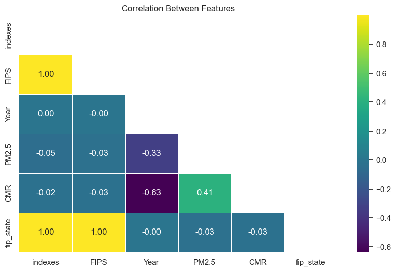

```python
# Create the plot
plt.figure(figsize=(10,6))
matrix = df_annualcounty_pm25_cmrCorr
mask = np.triu(np.ones_like(matrix, dtype=float))
sns.heatmap(df_annualcounty_pm25_cmrCorr,
           annot=True,
           linewidths=.5,
           cmap='viridis',
           fmt= '.2f',
           mask=mask)

# Specify the name of the plot
plt.title('Correlation Between Features')
plt.show()
```

There is a weak positive correlation between PM2.5 levels and cardiovascular mortality risk (CMR), with a correlation coefficient (r) of 0.41. This suggests that higher levels of air pollution, specifically fine particulate matter (PM2.5), are modestly associated with increased cardiovascular mortality. Additionally, there is a moderately strong negative correlation between the year and CMR (r = –0.63), indicating a possible declining trend in cardiovascular mortality over time.

```python
df_merged_state_countyCorr = df_merged_state_county.corr(numeric_only=True)
#df_merged_state_countyCorr #view output
```

```python
# Set seaborn themes
sns.set_theme(style='white')
sns.color_palette('viridis', as_cmap=True)
```

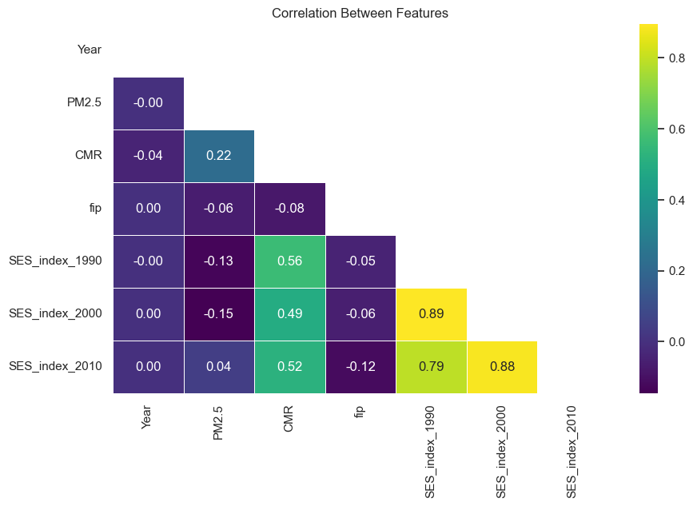

```python
# Create the plot
plt.figure(figsize=(10,6))
matrix = df_merged_state_countyCorr
mask = np.triu(np.ones_like(matrix, dtype=float))
sns.heatmap(df_merged_state_countyCorr,
           annot=True,
           linewidths=.5,
           cmap='viridis',
           fmt= '.2f',
           mask=mask)

# Specify the name of the plot
plt.title('Correlation Between Features')
plt.show()
```

### Findings

Its worth noting that this heat map suggests from the correlation values between socio-economic indexes and cardiovascular mortality rate that cardiomortality rate increases as socioeconomic status index increases and this is in contrast to research that suggests that a higher socioeconomic status is associated with a lower CMR due to better health habits and healthcare access. Some possible reasons for this correlation may be due to confounding by region or other variables and could also be due SES indices capturing complexities such as counties with much older poupulation etc.

```python
# Hypothesis test
from scipy.stats import ttest_ind

# Hypothesis "States/Counties with higher PM2.5 levels have higher CMR"
high_pm25 = df_merged_state_county[df_merged_state_county['PM2.5'] > df_merged_state_county['PM2.5'].median()]['CMR']
low_pm25 = df_merged_state_county[df_merged_state_county['PM2.5'] <= df_merged_state_county['PM2.5'].median()]['CMR']

# Perform t-test
t_stat, p_value = ttest_ind(high_pm25, low_pm25)
print(f"t-statistic: {t_stat}, p-value: {p_value}")
```

```
t-statistic: 7.1673660317328, p-value: 8.96756932006852e-13
```

### Findings.

There is a statistically significant difference in the CMR between states/counties with high PM2.5 levels than those with low PM2.5 levels.

##### Associations between socioeconomic factors (poverty, education, and health insurance) and cardiovascular mortality rates across some U.S. states

```python
#Correlation Analysis
df_acs_pm25_cmr_ses_index_state_combinedCorr = df_acs_pm25_cmr_ses_index_state_combined[['poverty_rate', 'uninsured_rate','education_percent_educated_18', 'PM2.5','CMR']].corr()
#df_acs_pm25_cmr_ses_index_state_combinedCorr #view output
```

```python
# Set seaborn themes
sns.set_theme(style='white')
sns.color_palette('viridis', as_cmap=True)
```

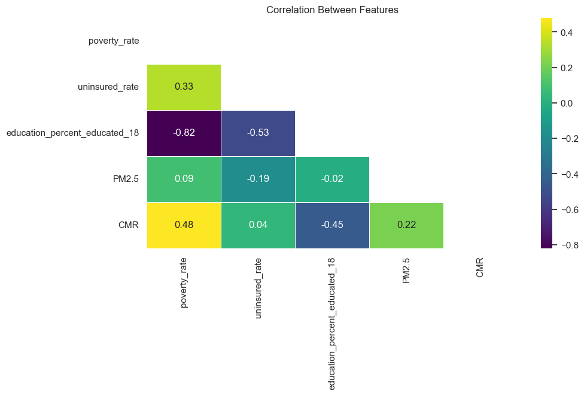

```python
# Create the plot
plt.figure(figsize=(10,5))
matrix = df_acs_pm25_cmr_ses_index_state_combinedCorr
mask = np.triu(np.ones_like(matrix, dtype=float))
sns.heatmap(df_acs_pm25_cmr_ses_index_state_combinedCorr,
           annot=True,
           linewidths=.5,
           cmap='viridis',
           fmt= '.2f',
           mask=mask)

# Specify the name of the plot
plt.title('Correlation Between Features')
plt.show()
```

##### Boxplots on SES and CMR: They reveal systematic differences in CMR across socioeconomic groups.

### Findings.

This suggests a modestly positive correlation between the poverty rate,pm2.5 and cardiovascularmortality rate, with a correlation coefficient (r) of 0.48 and 0.22 indicating that increasing poverty levels and pm2.5 levels may be associated with higher CMR.

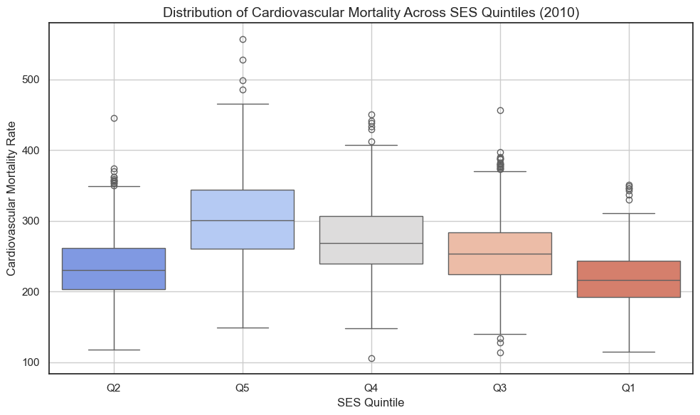

```python
plt.figure(figsize=(10, 6))
sns.boxplot(data=df_merged_state_county, x='SES_quintile_2010', y='CMR', palette='coolwarm')
plt.title('Distribution of Cardiovascular Mortality Across SES Quintiles (2010)', fontsize=14)
plt.xlabel('SES Quintile')
plt.ylabel('Cardiovascular Mortality Rate')
plt.grid(True)
plt.tight_layout()
plt.show()
```

### Findings.

The contrast noticed in the boxplots between the influence of social classification based on socioeconomic status on cardiovascular mortality and the influence of poverty levels classified into tertiles on cardiovascular mortality suggests that while socioeconomic status and poverty are related, their impacts on cardiovascular health may be distinct. Socioeconomic status likely captures broader factors, such as access to quality education, stable employment, and social support networks, whereas poverty levels focus more narrowly on income deprivation. Further statistical analysis is important to determine the significance of the observed differences.

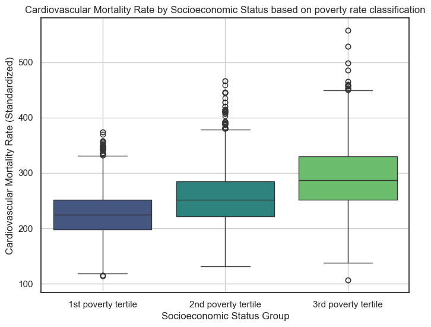

```python
# Categorize states into Low, Medium, High SES Groups
df_acs_pm25_cmr_ses_index_state_combined['SES_Group'] = pd.qcut(df_acs_pm25_cmr_ses_index_state_combined['poverty_rate'], q=3, labels=['1st poverty tertile', '2nd poverty tertile', '3rd poverty tertile'])

# Boxplot
plt.figure(figsize=(8,6))
sns.boxplot(data=df_acs_pm25_cmr_ses_index_state_combined, x="SES_Group", y="CMR", palette="viridis")
plt.title("Cardiovascular Mortality Rate by Socioeconomic Status based on poverty rate classification")
plt.xlabel("Socioeconomic Status Group")
plt.ylabel("Cardiovascular Mortality Rate (Standardized)")
plt.grid(True)
plt.show()
```

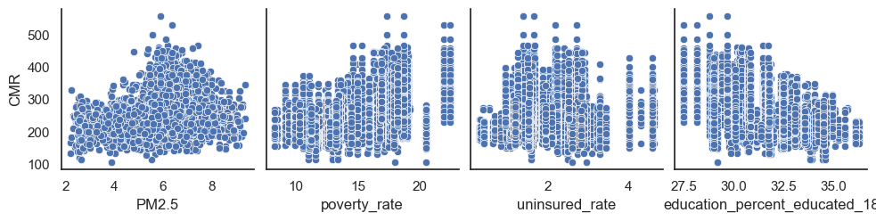

```python
sns.pairplot(
    df_acs_pm25_cmr_ses_index_state_combined,
    x_vars=["PM2.5", "poverty_rate", "uninsured_rate","education_percent_educated_18"],
    y_vars=["CMR"]
)



plt.show()
```

#### This pairplot above provides a matrix of scatter plots, examining how different socioeconomic factors (poverty, education, insurance) relate to Cardiomortality rate (CMR).

### Findings.

The pairwise relationships shows that higher pm2.5 rates may be associated with increased CMR and shows that lower education and higher poverty rates may be associated with increased CMR.

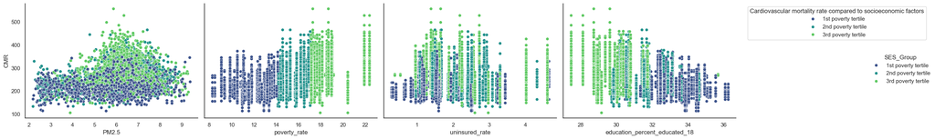

```python
sns.pairplot(
    df_acs_pm25_cmr_ses_index_state_combined,
    x_vars=["PM2.5", "poverty_rate", "uninsured_rate","education_percent_educated_18"],
    y_vars=["CMR"],
    hue="SES_Group",
    palette="viridis" ,
    height=4,
    aspect=1.5
)

# Add a legend
plt.legend(title="Cardiovascular mortality rate compared to socioeconomic factors", bbox_to_anchor=(1.05, 1), loc='upper left')

# Adjust layout
plt.tight_layout()

# Show the plot
plt.show()
```

### Scatter Plots above of CMR in relation to PM2.5 and Socioeconomic Indicators:

These plots demonstrate that environmental and social determinants influence CMR. It suggests a differential impact of PM2.5 on cardiovascular mortality across socioeconomic status groups, potentially indicating increased vulnerability in lower SES communities who may experience elevated CMR even at lower pollution levels, and further reveals socioeconomic differences wherein higher poverty and uninsured rates, coupled with lower education levels (probably indicative of lower SES), are associated with increased CMR, while the stratification by SES Group allows for a preliminary exploration of the intersectional nature of these factors by showing how the relationship between one socioeconomic indicator and CMR may vary across different SES levels.

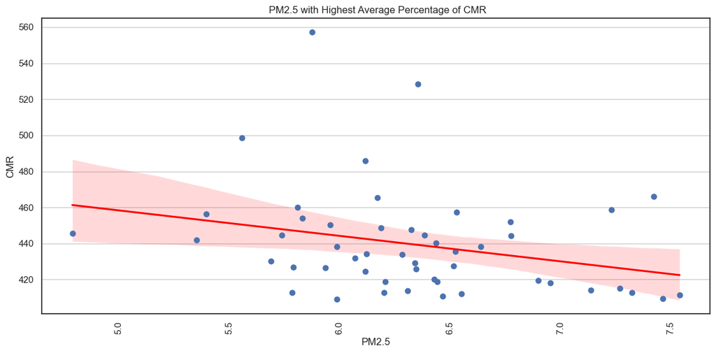

```python
# Group by variable1 and calculate the average percentage of variable2 for each variable1
averageVariable1 = df_acs_pm25_cmr_ses_index_state_combined.groupby('PM2.5')['CMR'].mean()

# Sort variable1 based on the highest average percentage of variable2
maxVariable1 = averageVariable1.sort_values(ascending=False).head(50)

# Create a scatter plot
plt.figure(figsize=(12, 6))
sns.regplot(x=maxVariable1.index, y=maxVariable1.values, scatter=True, line_kws={'color': 'red'})
plt.scatter(maxVariable1.index, maxVariable1.values)
plt.xlabel('PM2.5')
plt.ylabel('CMR')
plt.title(' PM2.5 with Highest Average Percentage of CMR')
plt.xticks(rotation=90)
plt.grid(axis='y')
plt.tight_layout()
# Show the visualization
plt.show()
```

### This plot above and below explores the impact of air pollution (PM2.5) on cardiovascular mortality.

### Findings.

Higher PM2.5 levels appear to be linked to an increase in CMR when variables are standardized, reinforcing environmental concerns in cardiovascular health. But higher PM2.5 levels appear to be linked to a decrease in CMR when variables are averaged.

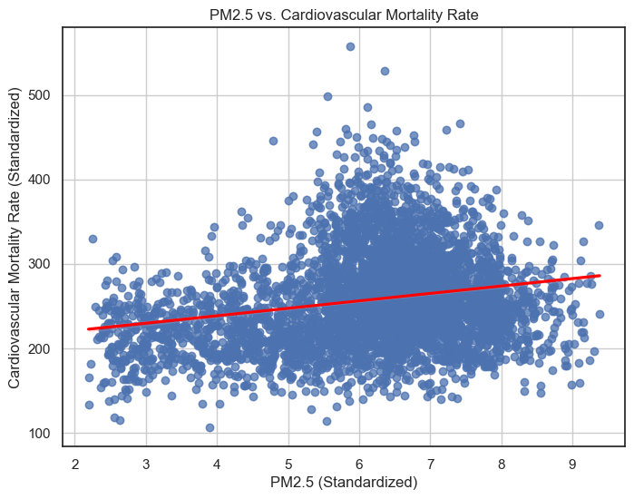

```python
# Scatter Plot: PM2.5 vs Cardiovascular Mortality Rate
plt.figure(figsize=(8,6))
sns.regplot(data=df_acs_pm25_cmr_ses_index_state_combined, x="PM2.5", y="CMR", scatter_kws={'alpha':0.5}, line_kws={'color':'red'})
plt.title("PM2.5 vs. Cardiovascular Mortality Rate")
plt.xlabel("PM2.5 (Standardized)")
plt.ylabel("Cardiovascular Mortality Rate (Standardized)")
plt.grid(True)
plt.show()
```

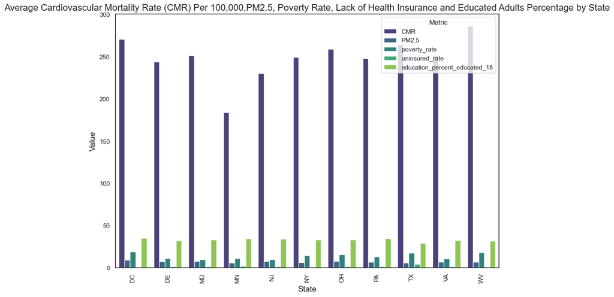

```python
# States of interest
states = ['DC', 'MD', 'VA', 'WV', 'PA', 'DE', 'MN', 'NY', 'NJ', 'TX', 'OH']
df_filtered = df_acs_pm25_cmr_ses_index_state_combined[df_acs_pm25_cmr_ses_index_state_combined['state'].isin(states)]

# Group by state and calculate mean CMR and Hypertension Rate
df_grouped = df_filtered.groupby('state')[['CMR', 'PM2.5','poverty_rate','uninsured_rate','education_percent_educated_18']].mean().reset_index()

# Join the grouped dataframe for plotting
df_melted = df_grouped.melt(
    id_vars=['state'],
    value_vars=['CMR', 'PM2.5','poverty_rate','uninsured_rate','education_percent_educated_18'],
    var_name='Metric',
    value_name='Value'
)

# Create a side-by-side bar plot
plt.figure(figsize=(12, 8))
sns.barplot(
    x='state',
    y='Value',
    hue='Metric',
    data=df_melted,
    palette='viridis'
)
plt.title('Average Cardiovascular Mortality Rate (CMR) Per 100,000,PM2.5, Poverty Rate, Lack of Health Insurance and Educated Adults Percentage by State', fontsize=16)
plt.xlabel('State', fontsize=14)
plt.ylabel('Value', fontsize=14)
plt.xticks(rotation=90)
plt.legend(title='Metric')
plt.show()
```

### This scatter plot examines the correlation between the poverty rate and cardiovascular mortality rates.

### Findings.

The plot shows a positive correlation with standardized and non-standardized variables, indicating that states with higher poverty rates may have some influence on increased cardiovascular mortality rates.

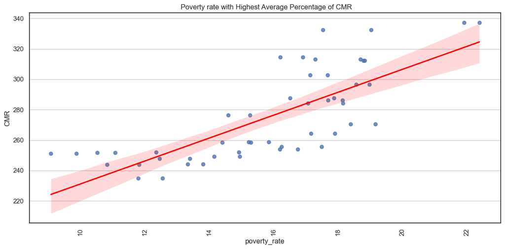

```python
# Group by variable1 and calculate the average percentage of variable2 for each variable1
averageVariable1 = df_acs_pm25_cmr_ses_index_state_combined.groupby('poverty_rate')['CMR'].mean()

# Sort variable1 based on the highest average percentage of variable2
maxVariable1 = averageVariable1.sort_values(ascending=False).head(50)

# Create a scatter plot
plt.figure(figsize=(12, 6))
sns.regplot(x=maxVariable1.index, y=maxVariable1.values, scatter=True, line_kws={'color': 'red'})
plt.xlabel('poverty_rate')
plt.ylabel('CMR')
plt.title(' Poverty rate with Highest Average Percentage of CMR')
plt.xticks(rotation=90)
plt.grid(axis='y')
plt.tight_layout()
# Show the visualization
plt.show()
```

### This scatter plot examines the correlation between the higher education rates and cardiovascular mortality rates.

### Findings.

The plot shows a potential negative correlation with standardized and non_standardized variables, indicating that states with higher educated citizen rates may have some influence on decreased cardiovascular mortality rates.

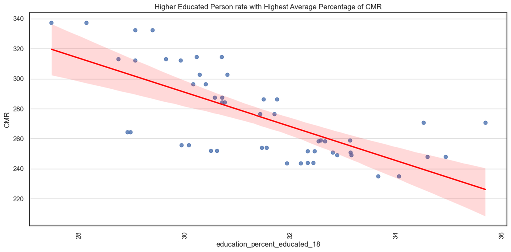

```python
# Group  by variable1 and calculate the average percentage of variable2 for each variable1
averageVariable1 = df_acs_pm25_cmr_ses_index_state_combined.groupby('education_percent_educated_18')['CMR'].mean()

# Sort variable1 based on the highest average percentage of variable2
maxVariable1 = averageVariable1.sort_values(ascending=False).head(50)

# Create a scatter plot
plt.figure(figsize=(12, 6))
sns.regplot(x=maxVariable1.index, y=maxVariable1.values, scatter=True, line_kws={'color': 'red'})
plt.xlabel('education_percent_educated_18')
plt.ylabel('CMR')
plt.title('Higher Educated Person rate with Highest Average Percentage of CMR')
plt.xticks(rotation=90)
plt.grid(axis='y')
plt.tight_layout()
# Show the visualization
plt.show()
```

### This scatter plot examines the correlation between the uninsured rate and cardiovascular mortality rates.

### Findings.

The plot shows a potential positive correlation, indicating that states with higher uninsured rates may have some influence on increased cardiovascular mortality rates.

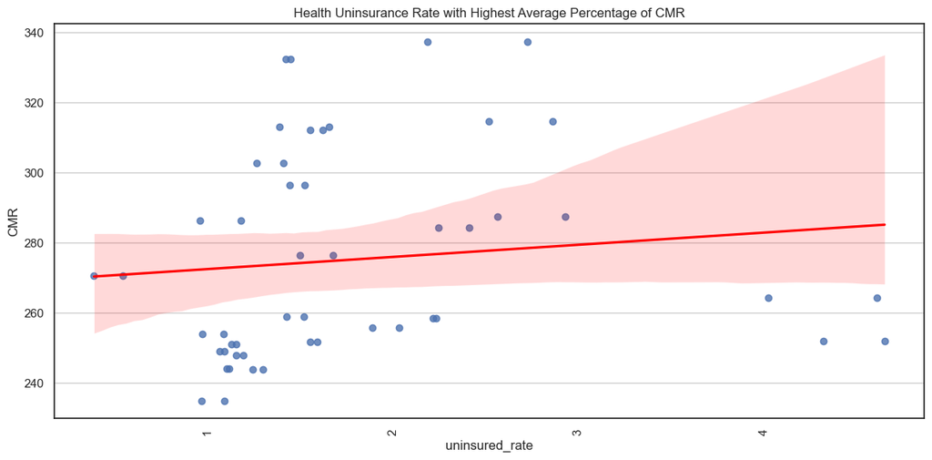

```python
#Group by variable1 and calculate the average percentage of variable2 for each variable1
averageVariable1 = df_acs_pm25_cmr_ses_index_state_combined.groupby('uninsured_rate')['CMR'].mean()

# Sort variable1 based on the highest average percentage of variable2
maxVariable1 = averageVariable1.sort_values(ascending=False).head(50)

# Create a scatter plot
plt.figure(figsize=(12, 6))
sns.regplot(x=maxVariable1.index, y=maxVariable1.values, scatter=True, line_kws={'color': 'red'})
plt.xlabel('uninsured_rate')
plt.ylabel('CMR')
plt.title('Health Uninsurance Rate with Highest Average Percentage of CMR')
plt.xticks(rotation=90)
plt.grid(axis='y')
plt.tight_layout()
# Show the visualization
plt.show()
```

```python
#  Plotly Scatter chart
import plotly.express as px

fig = px.scatter (df_acs_pm25_cmr_ses_index_state_combined,
x='poverty_rate',
y = 'CMR' ,
color = 'education_percent_educated_18',
title = 'The Interaction Between CVD Mortality, and Socioeconomic Status Factors( Poverty rate, higher education)',
labels={
"poverty_rate": "Poverty rate",
"CMR": "Cardiovascular Mortality Rates",
"education_percent_educated_18": "Rates of Population with Higher Education "
},
color_continuous_scale=px. colors. sequential.Viridis)
fig. show()
```

[interactive chart not shown]

```python
#  Plotly Scatter chart
import plotly.express as px

fig = px.scatter (df_acs_pm25_cmr_ses_index_state_combined,
x='PM2.5',
y = 'CMR' ,
color = 'uninsured_rate',
title = 'The Interaction Between CVD Mortality, PM2.5 and a Socioeconomic Status factor(uninsured health rate)',
labels={
"PM2.5": "Particulate Matter 2.5 levels",
"CMR": "Cardiovascular Mortality Rates",
"uninsured_rate": "Rates of Population Lacking Health Insurance "
},
color_continuous_scale=px. colors. sequential.Viridis)
fig. show()
```

[interactive chart not shown]

### Findings.

This visualization above provides a plot, examining how a socioeconomic factor(Health insurance) and PM2.5 relates to Cardiovascular Mortality. The relationships subtlely suggest that as PM2.5 Pollutant levels rise in combination with higher rates of lack of health insurance Cardiovascular Mortality may also rise.

### How does hypertension prevalence influence cardiovascular mortality rates?

```python
df_cvd_htn_mort_combined_reup_clean=df_cvd_htn_mort_combined_reup.drop(columns=['URL_cvdmort', 'URL_htnmort'])

df_cvd_htn_mort_combined_reup_clean.tail()
```

|  | YEAR | state | Cvdmortrate | Cvddeathcount | Htndxdeathrate | Htndxdeathcount |
| --- | --- | --- | --- | --- | --- | --- |
| 496 | 2005 | VA | 203.0 | 14192 | 7.9 | 549 |
| 497 | 2005 | WA | 180.5 | 10985 | 7.5 | 452 |
| 498 | 2005 | WV | 253.6 | 5538 | 11.6 | 253 |
| 499 | 2005 | WI | 190.6 | 11842 | 7.1 | 451 |
| 500 | 2005 | WY | 188.3 | 952 | 3.9 | 20 |

```python
#Correlation Analysis
df_cvd_htn_mort_combined_reup_cleanCorr = df_cvd_htn_mort_combined_reup_clean[['Cvdmortrate', 'Htndxdeathrate']].corr()
df_cvd_htn_mort_combined_reup_cleanCorr

from scipy.stats import pearsonr
#Pearson correlation and p-value
corr_coef, p_value = pearsonr(df_cvd_htn_mort_combined_reup_clean['Cvdmortrate'], df_cvd_htn_mort_combined_reup_clean['Htndxdeathrate'])

corr_coef,p_value
```

```
(0.2952786039775407, 1.5444236806717292e-11)
```

### Findings.

This suggests a weak positive relationship between Hypertension mortality rate and Cardiovascular disease mortality rate with a good significance level.

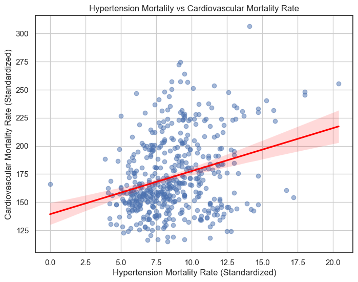

```python
# Scatter Plot: Hypertension Prevalence vs Cardiovascular Mortality Rate
plt.figure(figsize=(8,6))
sns.regplot(data=df_cvd_htn_mort_combined_reup_clean, x="Htndxdeathrate", y="Cvdmortrate", scatter_kws={'alpha':0.5}, line_kws={'color':'red'})
plt.title("Hypertension Mortality vs Cardiovascular Mortality Rate")
plt.xlabel("Hypertension Mortality Rate (Standardized)")
plt.ylabel("Cardiovascular Mortality Rate (Standardized)")
plt.grid(True)
plt.show()
```

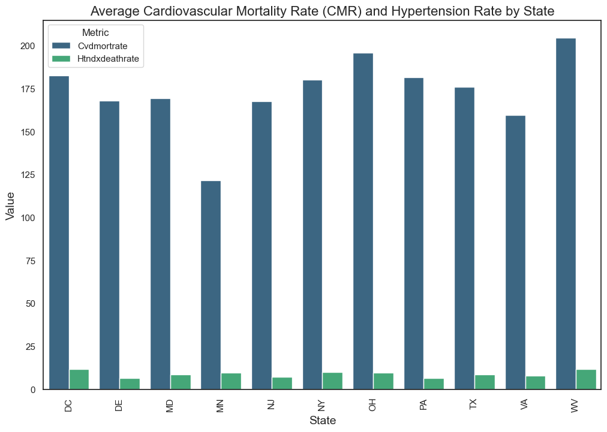

```python
# States of interest
states = ['DC', 'MD', 'VA', 'WV', 'PA', 'DE', 'MN', 'NY', 'NJ', 'TX', 'OH']
df_filtered = df_cvd_htn_mort_combined_reup[df_cvd_htn_mort_combined_reup['state'].isin(states)]

# Group by state and calculate mean CMR and Hypertension Rate
df_grouped = df_filtered.groupby('state')[['Cvdmortrate', 'Htndxdeathrate']].mean().reset_index()

# Join the grouped dataframe for plotting
df_melted = df_grouped.melt(
    id_vars=['state'],
    value_vars=['Cvdmortrate', 'Htndxdeathrate'],
    var_name='Metric',
    value_name='Value'
)

# Create a side-by-side bar plot
plt.figure(figsize=(12, 8))
sns.barplot(
    x='state',
    y='Value',
    hue='Metric',
    data=df_melted,
    palette='viridis'
)
plt.title('Average Cardiovascular Mortality Rate (CMR) and Hypertension Rate by State', fontsize=16)
plt.xlabel('State', fontsize=14)
plt.ylabel('Value', fontsize=14)
plt.xticks(rotation=90)
plt.legend(title='Metric')
plt.show()
```

The visualizations in the figure above are expected for Cardiovascular disease mortality and hypertensive disease rates considering that though hypertension is a high risk factor for cardiovascular Death and CMR, Cardiovascular disease and mortality can be due to a vast number of other conditions.

Regression Analysis: The regression results quantify how various factors contribute to CMR.

```python
# independent and dependent variables
X = df_cvd_htn_mort_combined_reup_clean[['Htndxdeathrate']]
y = df_cvd_htn_mort_combined_reup_clean['Cvdmortrate']

import statsmodels.api as sm
# intercept
X = sm.add_constant(X)

# Fit the regression model
model = sm.OLS(y, X).fit()

# Display summary statistics
model.summary()
```

OLS Regression Results

| Dep. Variable: | Cvdmortrate | R-squared: | 0.087 |
| --- | --- | --- | --- |
| Model: | OLS | Adj. R-squared: | 0.085 |
| Method: | Least Squares | F-statistic: | 47.66 |
| Date: | Sat, 19 Apr 2025 | Prob (F-statistic): | 1.54e-11 |
| Time: | 02:36:09 | Log-Likelihood: | -2434.0 |
| No. Observations: | 501 | AIC: | 4872. |
| Df Residuals: | 499 | BIC: | 4880. |
| Df Model: | 1 |  |  |
| Covariance Type: | nonrobust |  |  |

|  | coef | std err | t | P>\|t\| | [0.025 | 0.975] |
| --- | --- | --- | --- | --- | --- | --- |
| const | 139.2546 | 4.984 | 27.940 | 0.000 | 129.462 | 149.047 |
| Htndxdeathrate | 3.8284 | 0.555 | 6.904 | 0.000 | 2.739 | 4.918 |

| Omnibus: | 30.390 | Durbin-Watson: | 1.994 |
| --- | --- | --- | --- |
| Prob(Omnibus): | 0.000 | Jarque-Bera (JB): | 34.272 |
| Skew: | 0.629 | Prob(JB): | 3.61e-08 |
| Kurtosis: | 3.248 | Cond. No. | 32.5 |

Notes:  
[1] Standard Errors assume that the covariance matrix of the errors is correctly specified.

### Findings.

Visualizations show that though Hypertension mortality rate may have some influence on Cardiovascular moratlity rate, its influence is largely weak which is expected as CMR can be be linked to variety of factors which may sometimes be inter-related to hypertension. Furthermore, our regression model shows a statistically significant relationship between Hypertension-related death rate and Cardiovascular mortality rate. The positive and significant coefficient for Hypertension-related death rates suggests that higher hypertension-related death rates are associated with higher cardiovascular mortality rates and this gives some insight on the influence of hypertension prevalence on cardiovascular mortality rates albeit the low r-squared value (0.087) indicates that while hypertension-related death rates are significant, they explain only a small portion (8.7%) of the variation in cardiovascular mortality rates. This could mean that other conditions or factors like PM2.5 levels, socioeconomic factors are important and should be included as strong influences.

```python
# X and Y variables
X_variable = 'CMR'
y_variables = ['PM2.5']

# Add a intercept to the independent variables
X = sm.add_constant(df_acs_pm25_cmr_ses_index_state_combined[y_variables])
y = df_acs_pm25_cmr_ses_index_state_combined[X_variable]

# Fit the OLS model
model = sm.OLS(y, X).fit()

# Print the model summary
print(model.summary())
```

```
                            OLS Regression Results
==============================================================================
Dep. Variable:                    CMR   R-squared:                       0.047
Model:                            OLS   Adj. R-squared:                  0.047
Method:                 Least Squares   F-statistic:                     422.0
Date:                Sat, 19 Apr 2025   Prob (F-statistic):           1.47e-91
Time:                        02:36:09   Log-Likelihood:                -46324.
No. Observations:                8528   AIC:                         9.265e+04
Df Residuals:                    8526   BIC:                         9.267e+04
Df Model:                           1
Covariance Type:            nonrobust
==============================================================================
                 coef    std err          t      P>|t|      [0.025      0.975]
------------------------------------------------------------------------------
const        203.2342      2.714     74.888      0.000     197.914     208.554
PM2.5          8.8104      0.429     20.541      0.000       7.970       9.651
==============================================================================
Omnibus:                      690.091   Durbin-Watson:                   0.832
Prob(Omnibus):                  0.000   Jarque-Bera (JB):              908.627
Skew:                           0.704   Prob(JB):                    4.95e-198
Kurtosis:                       3.759   Cond. No.                         29.3
==============================================================================

Notes:
[1] Standard Errors assume that the covariance matrix of the errors is correctly specified.
```

```python
# X and Y variables
X_variable = 'CMR'
y_variables = ["uninsured_rate",'PM2.5']

# Add a intercept to the independent variables
X = sm.add_constant(df_acs_pm25_cmr_ses_index_state_combined[y_variables])
y = df_acs_pm25_cmr_ses_index_state_combined[X_variable]

# Fit the OLS model
model = sm.OLS(y, X).fit()

# Print the model summary
print(model.summary())
```

```
                            OLS Regression Results
==============================================================================
Dep. Variable:                    CMR   R-squared:                       0.054
Model:                            OLS   Adj. R-squared:                  0.054
Method:                 Least Squares   F-statistic:                     242.2
Date:                Sat, 19 Apr 2025   Prob (F-statistic):          4.74e-103
Time:                        02:36:09   Log-Likelihood:                -46294.
No. Observations:                8528   AIC:                         9.259e+04
Df Residuals:                    8525   BIC:                         9.262e+04
Df Model:                           2
Covariance Type:            nonrobust
==================================================================================
                     coef    std err          t      P>|t|      [0.025      0.975]
----------------------------------------------------------------------------------
const            189.3197      3.250     58.255      0.000     182.949     195.690
uninsured_rate     5.1492      0.667      7.722      0.000       3.842       6.456
PM2.5              9.4450      0.435     21.699      0.000       8.592      10.298
==============================================================================
Omnibus:                      703.300   Durbin-Watson:                   0.843
Prob(Omnibus):                  0.000   Jarque-Bera (JB):              937.813
Skew:                           0.707   Prob(JB):                    2.27e-204
Kurtosis:                       3.801   Cond. No.                         36.8
==============================================================================

Notes:
[1] Standard Errors assume that the covariance matrix of the errors is correctly specified.
```

```python
# X and Y variables
X_variable = 'CMR'
y_variables = ['poverty_rate', 'PM2.5']

# Add a intercept to the independent variables
X = sm.add_constant(df_acs_pm25_cmr_ses_index_state_combined[y_variables])
y = df_acs_pm25_cmr_ses_index_state_combined[X_variable]

# Fit the OLS model
model = sm.OLS(y, X).fit()

# Print the model summary
print(model.summary())
```

```
                            OLS Regression Results
==============================================================================
Dep. Variable:                    CMR   R-squared:                       0.262
Model:                            OLS   Adj. R-squared:                  0.262
Method:                 Least Squares   F-statistic:                     1511.
Date:                Sat, 19 Apr 2025   Prob (F-statistic):               0.00
Time:                        02:36:09   Log-Likelihood:                -45236.
No. Observations:                8528   AIC:                         9.048e+04
Df Residuals:                    8525   BIC:                         9.050e+04
Df Model:                           2
Covariance Type:            nonrobust
================================================================================
                   coef    std err          t      P>|t|      [0.025      0.975]
--------------------------------------------------------------------------------
const           69.7983      3.591     19.439      0.000      62.760      76.837
poverty_rate     9.3889      0.189     49.780      0.000       9.019       9.759
PM2.5            7.1237      0.379     18.792      0.000       6.381       7.867
==============================================================================
Omnibus:                      487.993   Durbin-Watson:                   1.059
Prob(Omnibus):                  0.000   Jarque-Bera (JB):              645.338
Skew:                           0.540   Prob(JB):                    7.36e-141
Kurtosis:                       3.807   Cond. No.                         114.
==============================================================================

Notes:
[1] Standard Errors assume that the covariance matrix of the errors is correctly specified.
```

```python
# X and Y variables
X_variable = 'CMR'
y_variables = ['poverty_rate', "uninsured_rate", 'PM2.5']

# Add a intercept to the independent variables
X = sm.add_constant(df_acs_pm25_cmr_ses_index_state_combined[y_variables])
y = df_acs_pm25_cmr_ses_index_state_combined[X_variable]

# Fit the OLS model
model = sm.OLS(y, X).fit()

# Print the model summary
print(model.summary())
```

```
                            OLS Regression Results
==============================================================================
Dep. Variable:                    CMR   R-squared:                       0.270
Model:                            OLS   Adj. R-squared:                  0.270
Method:                 Least Squares   F-statistic:                     1051.
Date:                Sat, 19 Apr 2025   Prob (F-statistic):               0.00
Time:                        02:36:09   Log-Likelihood:                -45188.
No. Observations:                8528   AIC:                         9.038e+04
Df Residuals:                    8524   BIC:                         9.041e+04
Df Model:                           3
Covariance Type:            nonrobust
==================================================================================
                     coef    std err          t      P>|t|      [0.025      0.975]
----------------------------------------------------------------------------------
const             76.3900      3.633     21.026      0.000      69.268      83.512
poverty_rate      10.0973      0.201     50.250      0.000       9.703      10.491
uninsured_rate    -6.1647      0.627     -9.824      0.000      -7.395      -4.935
PM2.5              6.2367      0.388     16.089      0.000       5.477       6.997
==============================================================================
Omnibus:                      510.461   Durbin-Watson:                   1.065
Prob(Omnibus):                  0.000   Jarque-Bera (JB):              669.638
Skew:                           0.561   Prob(JB):                    3.89e-146
Kurtosis:                       3.790   Cond. No.                         117.
==============================================================================

Notes:
[1] Standard Errors assume that the covariance matrix of the errors is correctly specified.
```

```python
# X and Y variables
X_variable = 'CMR'
y_variables = ['poverty_rate', 'education_percent_educated_18', "uninsured_rate", 'PM2.5']

# Add a intercept to the independent variables
X = sm.add_constant(df_acs_pm25_cmr_ses_index_state_combined[y_variables])
y = df_acs_pm25_cmr_ses_index_state_combined[X_variable]

# Fit the OLS model
model = sm.OLS(y, X).fit()

# Print the model summary
print(model.summary())
```

```
                            OLS Regression Results
==============================================================================
Dep. Variable:                    CMR   R-squared:                       0.303
Model:                            OLS   Adj. R-squared:                  0.303
Method:                 Least Squares   F-statistic:                     926.8
Date:                Sat, 19 Apr 2025   Prob (F-statistic):               0.00
Time:                        02:36:09   Log-Likelihood:                -44990.
No. Observations:                8528   AIC:                         8.999e+04
Df Residuals:                    8523   BIC:                         9.003e+04
Df Model:                           4
Covariance Type:            nonrobust
=================================================================================================
                                    coef    std err          t      P>|t|      [0.025      0.975]
-------------------------------------------------------------------------------------------------
const                           512.5388     21.964     23.336      0.000     469.485     555.593
poverty_rate                      4.8573      0.326     14.894      0.000       4.218       5.497
education_percent_educated_18   -10.8550      0.539    -20.122      0.000     -11.912      -9.798
uninsured_rate                  -12.5539      0.690    -18.182      0.000     -13.907     -11.200
PM2.5                             6.1614      0.379     16.267      0.000       5.419       6.904
==============================================================================
Omnibus:                      395.441   Durbin-Watson:                   1.111
Prob(Omnibus):                  0.000   Jarque-Bera (JB):              508.545
Skew:                           0.475   Prob(JB):                    3.72e-111
Kurtosis:                       3.727   Cond. No.                     1.53e+03
==============================================================================

Notes:
[1] Standard Errors assume that the covariance matrix of the errors is correctly specified.
[2] The condition number is large, 1.53e+03. This might indicate that there are
strong multicollinearity or other numerical problems.
```

### Findings.

The visualizations in this paper effectively reflect the relationship between cardiovascular mortality rates (CMR), air pollution (PM2.5), and socioeconomic factors such as poverty, education, and healthcare access(health uninsurance rate). The correlation map and regression analysis confirm that both environmental and social determinants significantly contribute to variations in CMR across different U.S. states. Higher PM2.5 exposure is associated with increased cardiovascular mortality, reinforcing concerns about air pollution's impact on heart disease. Lower socioeconomic status (SES) groups experience higher CMR, highlighting the role of poverty, education disparities and possibly other factors in cardiovascular health.

# Recommendations

The need for immediate and transformative action to achieve socio-environmental justice is clear, demanding that the burden of pollution no longer fall disproportionately on vulnerable communities. It is our hope that public health departments, environmental regulators, and local governments will use these findings to prioritize the most vulnerable communities for intervention and improve lives. To this end, a fundamental shift in policy and practice is required, beginning with a decisive four-year phased strategy. In the initial phase (Year 1 and 2), a re-evaluation and strengthening of air quality regulations must prioritize the most vulnerable. With "high burden" states to counties, identified through a confluence of high pollution levels and significant socioeconomic vulnerability, serving as pilot sites for enhanced emissions controls, robust and targeted environmental monitoring, and the enforcement of stricter policies for individuals, enterpreneurs, businesses and industries. This streamlined approach, necessitates moving beyond uniform PM2.5 thresholds to reflect the amplified risks faced by communities within the lowest SES quintiles. Concurrently, addressing the immediate health disparities requires a dedicated and phased investment in expanding healthcare access. In the initial phase, mobile health clinics should be strategically deployed into these pilot "high burden" zones, alongside steps to expand Medicaid eligibility. Building on the lessons learned, subsequent years should scale these successful outreach models to other rural and low-income areas exhibiting high pollution and cardiovascular mortality rates. This expansion should be supported by the direct allocation of increasing public health resources to these underserved regions. A proactive and systemic approach also demands a phased investment in the long-term resilience of these communities through education and workforce development. Starting in Year 1 within the pilot counties, data on SES and pollution exposure should be used to strategically channel initial education grants and adult learning initiatives. As the strategy progresses into Years 3 and 4, these efforts should be scaled, with a particular emphasis on fostering job creation programs in environmental remediation and the burgeoning clean energy sector, empowering residents to participate in the transition towards a healthier environment. To prevent the perpetuation of environmental injustice, a change in building and industrial permitting is essential, to be implemented system-wide over a four-year period. Commencing immediately, comprehensive Green Health Equity Impact or Impact Social Health Equity Impact Assessments must be mandated for all new and renewed permits, utilizing established environmental justice screening tools to ensure that potential hazards are not disproportionately sited in vulnerable zones and that new structures or renovations are environmentally suitable and promote clean air. This proactive approach aims to alleviate the systemic burdens in communities with this issue. The initiation of these programs in the pilot counties within Year 1 necessitates the immediate allocation of 100 million dollars in federal and state block grants, with matching funds actively sought from the Environmental Protection Agency (EPA) and the Centers for Disease Control and Prevention (CDC). Oversight of the implementation will be entrusted to joint EPA-Health and Human Services (HHS) regional task forces, strategically comprised of city county officials, state officials, environmental scientists, public health experts, physicians, data scientists, data analysts, urban planners, and health policy analysts with a dedicated focus on equity. Parallel legislative action must be pursued at the state level throughout this four-year period to empower effective enforcement of strengthened environmental regulations, ensuring accountability and long-term sustainability. Furthermore, all implemented programs, from the pilot phase onwards, must embed meaningful community engagement, ensure transparency in decision-making processes, and incorporate strict and ongoing impact evaluation to track progress and ensure accountability in the pursuit of socio-environmental justice for all communities, regardless of socioeconomic status. This research is intended to inform action and improve lives. The findings should be used by public health departments, environmental regulators, and local governments to prioritize the most vulnerable communities for intervention.